# Лабораторная работа №5

Операционные системы

Ежова А. М.

Российский университет дружбы народов, Москва, Россия

Факультет физико-математических и естественных наук

10 марат 2023

# Информация

## Докладчик

- Ежова Алиса Михайловна
- студентка НБИбд-01-22
- Российский университет дружбы народов
- https://github.com/AlisaEzhova

[figure not shown]

# Вводная часть

## Актуальность

- Эта лабораторная работа актуальная для студентов, кто хочет ознокомиться с файловой системой Linux.

## Цели и задачи

- Ознакомление с файловой системой Linux, её структурой, именами и содержанием каталогов. Приобретение практических навыков по применению команд для работы с файлами и каталогами, по управлению процессами (и работами), по проверке исполь- зования диска и обслуживанию файловой системы.

## Материалы и методы

- Процессор `pandoc` для входного формата Markdown
- Результирующие форматы
  - `pdf`
  - `html`
- Автоматизация процесса создания: `Makefile`

# Создание презентации

## Процессор `pandoc`

- Pandoc: преобразователь текстовых файлов
- Сайт: https://pandoc.org/
- Репозиторий: https://github.com/jgm/pandoc

## Формат `pdf`

- Использование LaTeX
- Пакет для презентации: beamer
- Тема оформления: `metropolis`

## Код для формата `pdf`

```yaml
slide_level: 2
aspectratio: 169
section-titles: true
theme: metropolis
```

## Формат `html`

- Используется фреймворк [reveal.js](https://revealjs.com/)
- Используется [тема](https://revealjs.com/themes/) `beige`

## Код для формата `html`

- Тема задаётся в файле `Makefile`

```
REVEALJS_THEME = beige
```

# Результаты

## Получающиеся форматы

- Полученный `pdf`-файл можно демонстрировать в любой программе просмотра `pdf`
- Полученный `html`-файл содержит в себе все ресурсы: изображения, css, скрипты

## Содержание исследования

1. Выполнила все примеры, приведенные в первой части описания лабораторной работы:

Примеры:

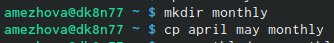

Копирование нескольких файлов

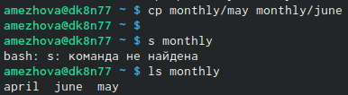

Копирование файлов в произвольном каталоге

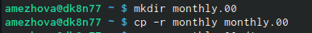

Копирование каталогов в текущем каталоге

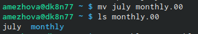

Перемещение файлов в другой каталог

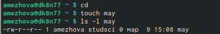

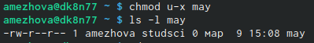

Лишение владельца права на выполнение

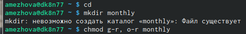

Каталог с запретом на чтение

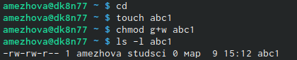

Файл с правом записи

2. Выполнила следующие действия и зафиксировала в отчете используемые при этом команды и результаты их выполнения.

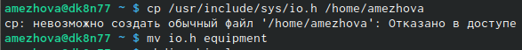

Новый файл

2.5) Создала в домашнем каталоге файл abc1 и скопировала его в каталог ~/ski.plases, назвала его equiplist2:

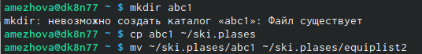

Создание нового файла

2.6) Создала каталог с именем equipment в каталоге ~/ski.plases:

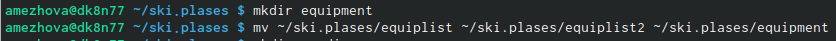

Создание нового каталога

2.7) Переместила файлы ~/ski.plases/equiplist и equiplist2 в каталог ~/ski.plases/equipment:

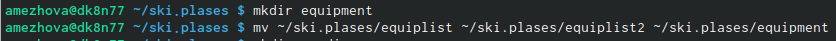

Создание нового каталога

2.8) Создала и переместилп каталог ~/newdir в каталог ~/ski.plases и назвала его plans.

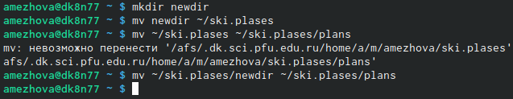

Перемещение каталогов

3. Определила опции команды chmod, необходимые для того, чтобы присвоить перечисленным ниже файлам выделенные права доступа, считая, что в начале таких прав нет:

3.1) drwxr–r– … australia

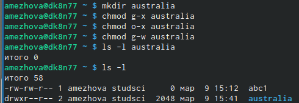

australia

3.2) drwx–x–x … play

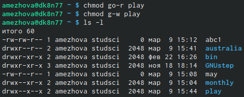

play

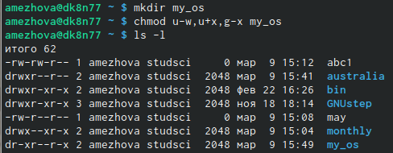

my_os

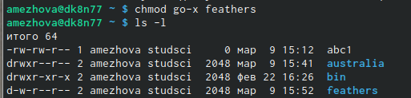

feathers

4. Проделала приведённые ниже упражнения, записывая в отчёт по лабораторной работе используемые при этом команды:

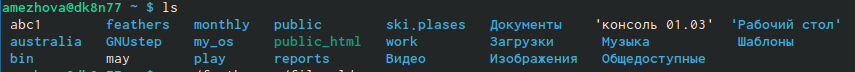

4.4) Скопировала каталог ~/play в каталог ~/fun

4.5) Переместила каталог ~/fun в каталог ~/play и назвала его games:

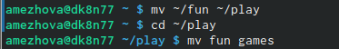

Перемещение каталога

5. Прочитайте man по командам mount, fsck, mkfs, kill:

man mount:

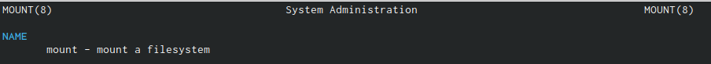

man mount

man fsck:

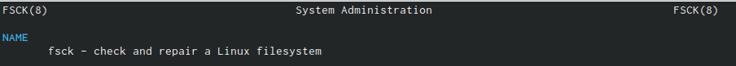

man fsck

man mkfs:

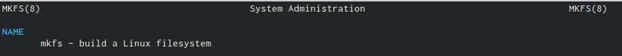

man mkfs

man kill:

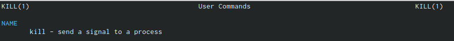

man kill

## Итоговый слайд

- Я ознакомилась с файловой системой Linux, её структурой, именами и содержанием каталогов. Приобрела практические навыки по применению команд для работы с файлами и каталогами, по управлению процессами (и работами), по проверке использования диска и обслуживанию файловой системы.